# Tree based methods

Hajin Jang

12/9/2025

## Concepts

#### Sketch of the tree

```
                 X1 < 1
                /      \
             yes        no
            /            \
         X2 < 1           5
        /     \
     yes       no
    /           \
 X1 < 0          15
 /    \
3    X2 < 0
     /    \
   10      0
```

#### Creating diagram

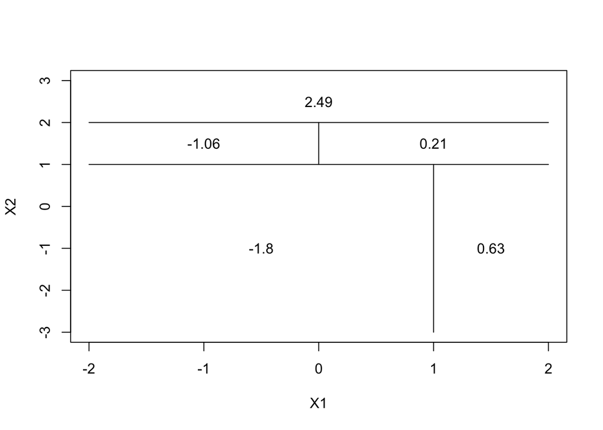

```r
par(xpd = NA)
plot(NA, NA, type = "n", xlim = c(-2, 2), ylim = c(-3, 3), xlab = "X1", ylab = "X2")
# X2 < 1
lines(x = c(-2, 2), y = c(1, 1))
# X1 < 1 with X2 < 1
lines(x = c(1, 1), y = c(-3, 1))
text(x = (-2 + 1)/2, y = -1, labels = c(-1.8))
text(x = 1.5, y = -1, labels = c(0.63))
# X2 < 2 with X2 >= 1
lines(x = c(-2, 2), y = c(2, 2))
text(x = 0, y = 2.5, labels = c(2.49))
# X1 < 0 with X2<2 and X2>=1
lines(x = c(0, 0), y = c(1, 2))
text(x = -1, y = 1.5, labels = c(-1.06))
text(x = 1, y = 1.5, labels = c(0.21))
```

## Tree-based methods

#### Training and test sets

```r
library(ISLR2)
attach(Carseats)
library(caret)
# Set seed
set.seed(2345)

trainval <- createDataPartition(y=Carseats$Sales, p=0.75, list=FALSE)

trval <- Carseats[trainval,] # this is a training set (tr+val combined)
tst <- Carseats[-trainval,] # this is a test set

train <- createDataPartition(y=trval$Sales, p=0.66, list=FALSE)
tr <- trval[train,]
val <- trval[-train,]

dim(Carseats)
```

```
## [1] 400  11
```

```r
dim(trval)
```

```
## [1] 301  11
```

```r
dim(tst)
```

```
## [1] 99 11
```

```r
dim(tr)
```

```
## [1] 201  11
```

```r
dim(val)
```

```
## [1] 100  11
```

```r
summary(trval)
```

```
##      Sales          CompPrice         Income        Advertising
##  Min.   : 0.000   Min.   : 77.0   Min.   : 21.00   Min.   : 0.000
##  1st Qu.: 5.400   1st Qu.:116.0   1st Qu.: 42.00   1st Qu.: 0.000
##  Median : 7.490   Median :126.0   Median : 68.00   Median : 6.000
##  Mean   : 7.531   Mean   :125.6   Mean   : 67.76   Mean   : 6.831
##  3rd Qu.: 9.320   3rd Qu.:136.0   3rd Qu.: 90.00   3rd Qu.:12.000
##  Max.   :16.270   Max.   :175.0   Max.   :120.00   Max.   :29.000
##    Population        Price        ShelveLoc        Age          Education
##  Min.   : 10.0   Min.   : 24.0   Bad   : 76   Min.   :25.00   Min.   :10.0
##  1st Qu.:148.0   1st Qu.:101.0   Good  : 65   1st Qu.:39.00   1st Qu.:12.0
##  Median :277.0   Median :118.0   Medium:160   Median :54.00   Median :14.0
##  Mean   :268.7   Mean   :116.3                Mean   :53.18   Mean   :13.9
##  3rd Qu.:394.0   3rd Qu.:131.0                3rd Qu.:66.00   3rd Qu.:16.0
##  Max.   :508.0   Max.   :185.0                Max.   :80.00   Max.   :18.0
##  Urban       US
##  No : 93   No :107
##  Yes:208   Yes:194
##
##
##
##
```

#### Regression tree

```r
library(tree)

# Set seed
set.seed(2345)

# Fit a regression tree to the trval set
carseats.tree = tree(Sales ~ ., data = trval)
summary(carseats.tree)
```

```
##
## Regression tree:
## tree(formula = Sales ~ ., data = trval)
## Variables actually used in tree construction:
## [1] "ShelveLoc"   "Price"       "Income"      "Population"  "Age"
## [6] "Advertising" "CompPrice"
## Number of terminal nodes:  13
## Residual mean deviance:  2.903 = 836 / 288
## Distribution of residuals:
##    Min. 1st Qu.  Median    Mean 3rd Qu.    Max.
## -3.9510 -1.2710  0.0781  0.0000  1.2900  3.8880
```

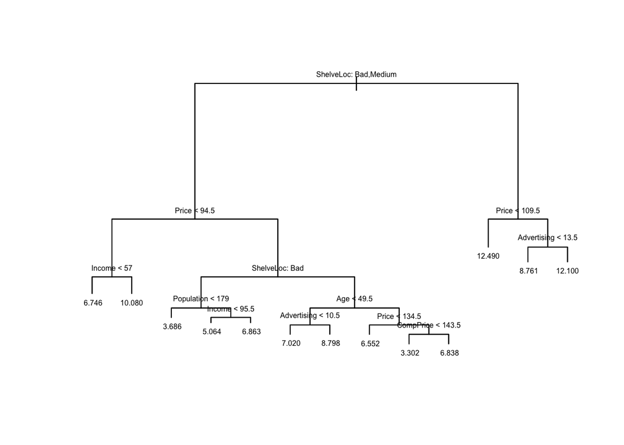

```r
# Plot the tree
plot(carseats.tree)
text(carseats.tree, pretty=0, cex=0.5)
```

```r
# Predict the test set outcomes and MSE
tree.pred <- predict(carseats.tree, newdata = tst)
tree.mse  <- mean( (tree.pred - tst$Sales)^2 )
tree.mse
```

```
## [1] 4.446654
```

The top split on ShelveLoc indicates that store display quality is the strongest predictor of Sales. Stores with Good vs. Bad/Medium shelving yield substantially different average sales levels. Subsequent splits show that Price consistently appears as a key determinant of Sales, with lower prices generally associated with higher predicted sales across branches. Other predictors, such as Income, Advertising, Age, Population, and CompPrice, provide finer adjustments to predictions within subgroups, but their effects are smaller compared to ShelveLoc and Price.

When predicting the test set outcomes, the regression tree achieved a test MSE of 4.446654, which reflects the average squared difference between predicted and observed sales in test data.

#### Cross-validation for tree-complexity

```r
# Set seed
set.seed(2345)

# Cross-validation
carseats.treecv <- cv.tree(carseats.tree)
str(carseats.treecv)
```

```
## List of 4
##  $ size  : int [1:12] 13 12 11 10 8 7 6 5 4 3 ...
##  $ dev   : num [1:12] 1407 1389 1406 1407 1399 ...
##  $ k     : num [1:12] -Inf 26.1 46 46.5 46.7 ...
##  $ method: chr "deviance"
##  - attr(*, "class")= chr [1:2] "prune" "tree.sequence"
```

```r
# Check the result
carseats.treecv$dev
```

```
##  [1] 1407.204 1388.502 1406.449 1406.942 1398.807 1519.358 1552.377 1552.377
##  [9] 1748.779 1742.382 1938.138 2557.570
```

```r
carseats.treecv$size
```

```
##  [1] 13 12 11 10  8  7  6  5  4  3  2  1
```

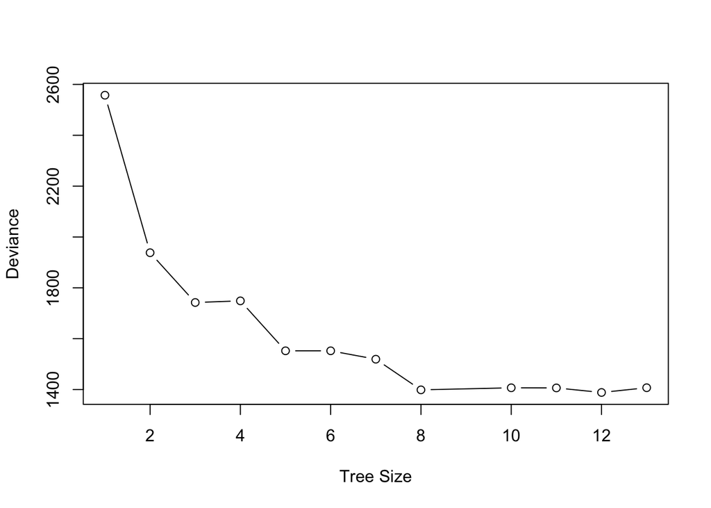

```r
# View in a plot
plot(carseats.treecv$size, carseats.treecv$dev, type="b", xlab="Tree Size", ylab="Deviance")
```

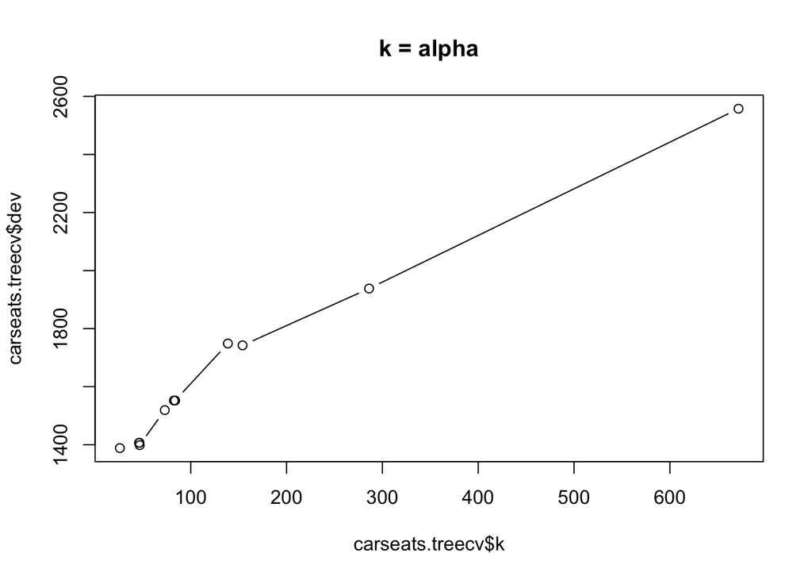

```r
plot(carseats.treecv$k, carseats.treecv$dev, type="b", main="k = alpha")
```

```r
# Minimum deviance size
best.size <- carseats.treecv$size[which.min(carseats.treecv$dev)]
best.size
```

```
## [1] 12
```

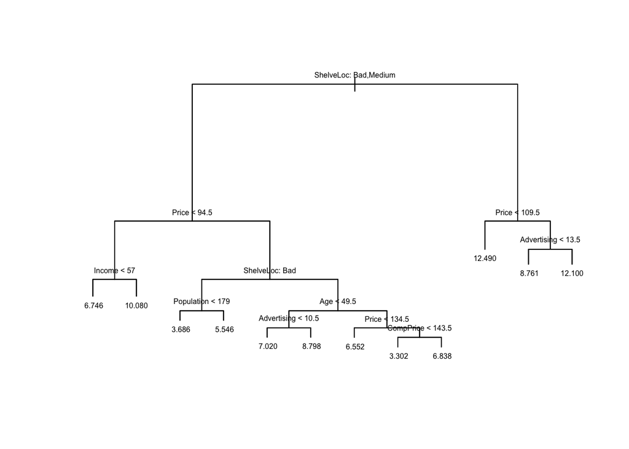

```r
# Prune the tree with best.size
car.prune <- prune.tree(carseats.tree, best = best.size)

plot(car.prune)
text(car.prune, pretty = 0, cex = 0.5)
```

```r
# Test MSE of the pruned tree
prune.pred <- predict(car.prune, newdata = tst)
prune.mse  <- mean((prune.pred - tst$Sales)^2)
prune.mse
```

```
## [1] 4.402967
```

```r
# Check whether prunning improved the prediction
tree.mse
```

```
## [1] 4.446654
```

```r
prune.mse
```

```
## [1] 4.402967
```

**Comment:** The cross-validation results show that deviance decreases rapidly as the tree grows from size 1 to about size 8, after which the improvement becomes minimal. The minimum cross-validated deviance occurs at tree size = 12, which suggests that a relatively large subtree provides the best balance between bias and variance for this dataset. Using this optimal size, I pruned the original tree to obtain a 12-terminal-node subtree. When evaluated on the test set, the pruned tree achieved a test MSE of 4.402967, compared with 4.446654 from the unpruned tree. Although the improvement is small, pruning does slightly reduce test error, indicating that the full tree was mildly overfitting the training data.

#### Bagging

```r
library(randomForest)
# number of predictors p
p <- ncol(trval) - 1

# Set seed
set.seed(2345)

# Bagging
car.bag <- randomForest(Sales ~ ., data = trval, mtry = p, importance = TRUE)
car.bag
```

```
##
## Call:
##  randomForest(formula = Sales ~ ., data = trval, mtry = p, importance = TRUE)
##                Type of random forest: regression
##                      Number of trees: 500
## No. of variables tried at each split: 10
##
##           Mean of squared residuals: 2.569741
##                     % Var explained: 69.52
```

```r
# Test MSE
bag.pred <- predict(car.bag, newdata = tst)
bag.mse  <- mean((bag.pred - tst$Sales)^2)
bag.mse
```

```
## [1] 2.022307
```

```r
# Important variables
importance(car.bag)
```

```
##                 %IncMSE IncNodePurity
## CompPrice   29.91196807    246.590028
## Income      12.60581660    143.557453
## Advertising 24.31337472    182.238838
## Population   0.07363792     85.157450
## Price       71.43940647    695.853600
## ShelveLoc   76.73384194    823.210237
## Age         24.32768250    228.885507
## Education    0.89227402     58.900455
## Urban       -3.47802751      9.558043
## US           0.31422340     10.675867
```

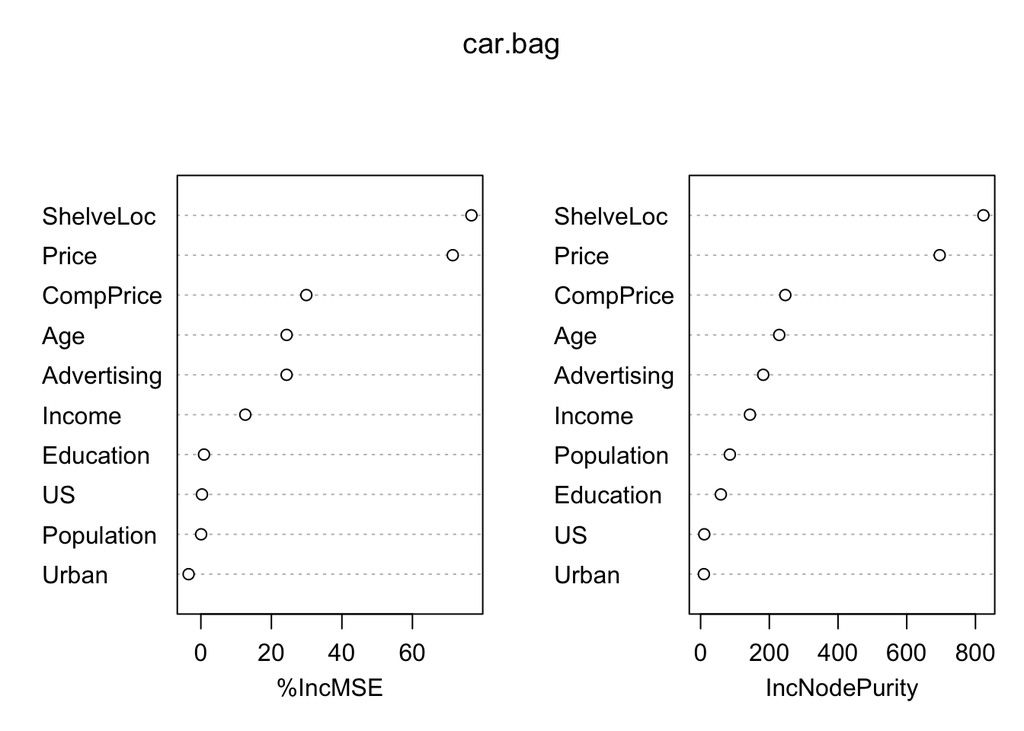

```r
varImpPlot(car.bag)
```

**Comment:** I fitted a random forest model with mtry equal to the total number of predictors (p). The model was trained on the trval set using 500 trees. When predicting Sales in the test set, the bagging model achieved a test MSE of approximately 2.022307, which is substantially lower than the MSE obtained from both the full regression tree (4.446654) and the pruned tree (4.402967). This indicates that bagging provides a large improvement in predictive accuracy by reducing variance through averaging many bootstrapped trees.

The variable importance results showed that ShelveLoc and Price were by far the most influential predictors of Sales, followed by CompPrice, Age, Advertising, and Income. These variables contributed the most to reducing prediction error across the ensemble of trees. In contrast, variables such as Education, US, Population, and Urban showed minimal importance, suggesting that they added little predictive value.

#### Random forest

```r
# Set seed
set.seed(2345)

# Default randomForest
car.rf.default <- randomForest(Sales ~ ., data = trval, importance = TRUE)
car.rf.default
```

```
##
## Call:
##  randomForest(formula = Sales ~ ., data = trval, importance = TRUE)
##                Type of random forest: regression
##                      Number of trees: 500
## No. of variables tried at each split: 3
##
##           Mean of squared residuals: 2.884463
##                     % Var explained: 65.79
```

```r
# Test MSE from the default mtry
rf.def.pred <- predict(car.rf.default, newdata = tst)
rf.def.mse  <- mean((rf.def.pred - tst$Sales)^2)
rf.def.mse
```

```
## [1] 2.344961
```

```r
# Compare multiple mtry
mtry.grid <- c(2, 4, 6, 8, p)
rf.mse <- numeric(length(mtry.grid))

for (i in seq_along(mtry.grid)) {
  set.seed(2345 + i)
  fit <- randomForest(Sales ~ ., data = trval,
                      mtry = mtry.grid[i],
                      importance = TRUE)

  pred <- predict(fit, newdata = tst)
  rf.mse[i] <- mean((pred - tst$Sales)^2)
}

data.frame(mtry = mtry.grid, Test_MSE = rf.mse)
```

```
##   mtry Test_MSE
## 1    2 2.571678
## 2    4 2.178100
## 3    6 2.059511
## 4    8 2.069844
## 5   10 2.004568
```

```r
# Best mtry
best.mtry <- mtry.grid[which.min(rf.mse)]
best.mtry
```

```
## [1] 10
```

```r
# Fit the model with the best mtry
set.seed(2345)
car.rf.best <- randomForest(Sales ~ ., data = trval,
                            mtry = best.mtry,
                            importance = TRUE)
importance(car.rf.best)
```

```
##                 %IncMSE IncNodePurity
## CompPrice   29.91196807    246.590028
## Income      12.60581660    143.557453
## Advertising 24.31337472    182.238838
## Population   0.07363792     85.157450
## Price       71.43940647    695.853600
## ShelveLoc   76.73384194    823.210237
## Age         24.32768250    228.885507
## Education    0.89227402     58.900455
## Urban       -3.47802751      9.558043
## US           0.31422340     10.675867
```

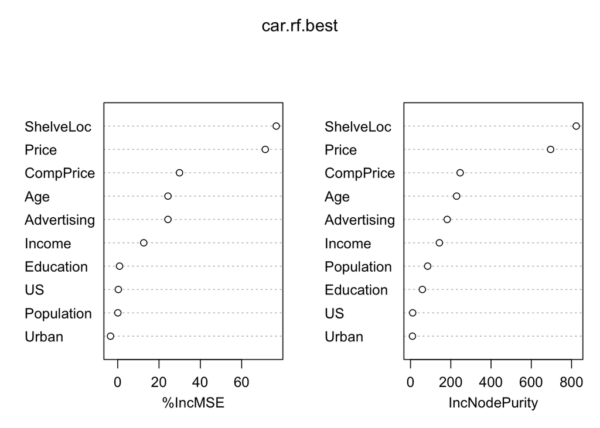

```r
varImpPlot(car.rf.best)
```

```r
# Test MSE of the optimal RF
rf.best.pred <- predict(car.rf.best, newdata = tst)
rf.best.mse  <- mean((rf.best.pred - tst$Sales)^2)
rf.best.mse
```

```
## [1] 2.022307
```

**Comment:** I fitted a random forest model to the trval set and first evaluated the default setting, which uses mtry = 3 variables at each split. The default model achieved a test MSE of 2.344961 (already improving upon both the single tree and the pruned tree).

To examine how the choice of mtry affects prediction performance, I fitted models with several values of mtry (2, 4, 6, 8, and p). The test MSE decreased as mtry increased, although mtry from 6 to 8 increased the test MSE slightly, from 2.059511 to 2.069844. The lowest MSE value was observed when mtry = 10 (using all predictors). The optimal random forest achieved a test MSE of 2.022307, which is nearly identical to the MSE obtained from bagging. This indicates that, for this dataset, increasing the number of variables considered at each split improves predictive accuracy.

The variable importance results show that ShelveLoc and Price are consistently the most influential predictors of Sales, followed by CompPrice, Age, Advertising, and Income. Variables such as US and Urban contribute very little to the predictive performance, as reflected by their low importance scores.

Overall, random forests substantially outperform single-tree models, and increasing m reduces error in this case. When mtry is set to its maximum (bagging), the model captures more of the strong predictors at each split, which leads to the lowest test MSE.